# Ch8: Feature engineering with recipes

This chapter focuses on feature engineering, the process of reformatting predictors to be used in the modeling process. This could be as simple as taking the ratio of two predictors to be used in the model, or by using another process like PCA to extract most of the meaningful variation from correlated predictors.

```r
ames_split <- initial_split(ames, prop = 0.8, strata = Sale_Price)
```

[output not shown]

Now we’ll focus on a subset of the predictors in the Ames housing data. Let’s get an idea of what their distributions look like.

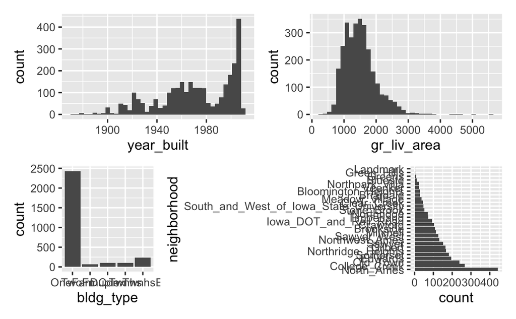

From these plots, the gross above-grade living area (`Gr_Liv_Area`) is right-skewed, thus an ordinary least squares regression model may benefit from applying a log transformation to this predictor. This preprocessing step, as well as the transformation of the remaining categorical variables into numeric variables to build the model matrix, could be accomplished by the formula in the generic linear model function call. However, we can bundle this pre-processing into a recipe for what “should be done” during the modeling process.

```r
(simple_ames_recipe <- recipe(
  sale_price ~ neighborhood + gr_liv_area + year_built + bldg_type,
  data = ames_train
) %>%
  step_log(gr_liv_area, base = 10) %>% # log transformation
  step_dummy(all_nominal_predictors())) # create dummy vars for all strings
```

```
Recipe

Inputs:
```

| role | #variables |
| --- | --- |
| outcome | 1 |
| predictor | 4 |

```
Operations:

Log transformation on gr_liv_area
Dummy variables from all_nominal_predictors()
```

One of the benefits of using this approach is that the recipe can be applied to different models without having to either: a) modify the original data; or b) explicitly define complex transformations for each model.

```r
extract_preprocessor(lm_workflow)
```

```
Recipe

Inputs:
```

| role | #variables |
| --- | --- |
| outcome | 1 |
| predictor | 4 |

```
Operations:

Log transformation on gr_liv_area
Dummy variables from all_nominal_predictors()
```

Now all of the pre-processing can be done by fitting the workflow and the training data.

| term | estimate | std.error | statistic | p.value |
| --- | --- | --- | --- | --- |
| (Intercept) | -0.681820406 | 0.2277165872 | -2.994162 | 2.781230e-03 |
| gr_liv_area | 0.624909786 | 0.0139592131 | 44.766835 | 1.358955e-315 |
| year_built | 0.001993628 | 0.0001154501 | 17.268313 | 6.191588e-63 |
| neighborhood_College_Creek | 0.016662367 | 0.0080727067 | 2.064037 | 3.912571e-02 |
| neighborhood_Old_Town | -0.035661502 | 0.0084434960 | -4.223547 | 2.498182e-05 |

Let’s add a new step to the recipe- we want to basically catch all of the infrequently occurring neighborhoods into a single factor level “other.” This can be accomplished in a single step with the `step_other()` function. We can see the results of the ammended recipe below.

```r
(simple_ames_recipe <- recipe(
  sale_price ~ neighborhood + gr_liv_area + year_built + bldg_type,
  data = ames_train
) %>%
  step_log(gr_liv_area, base = 10) %>%
  step_other(neighborhood, threshold = 0.01) %>%
  step_dummy(all_nominal_predictors()))
```

```
Recipe

Inputs:
```

| role | #variables |
| --- | --- |
| outcome | 1 |
| predictor | 4 |

```
Operations:

Log transformation on gr_liv_area
Collapsing factor levels for neighborhood
Dummy variables from all_nominal_predictors()
```

Now we’ll explore potential interaction terms to include in the model by looking at the interaction between gross above-ground living area and building type- in other words, does the effect of gross above-ground living area have an effect on the sale price that’s dependent on the type of building?

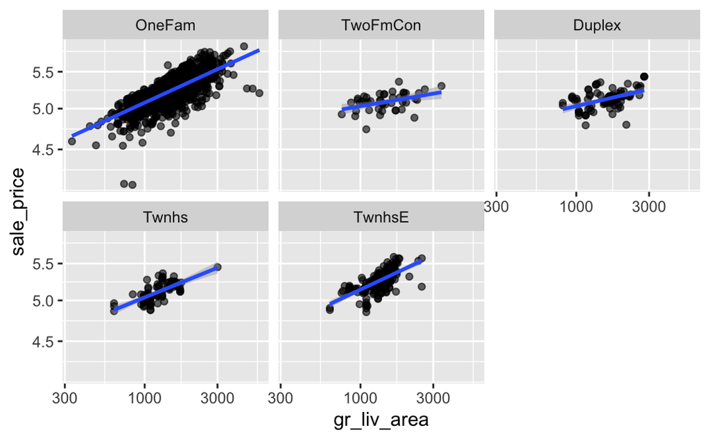

It looks like there is evidence of potential interactions between building type and the gross living area. Importantly, to fit interaction terms between these two variables, one numeric and one categorical, dummy variables first need to be created, then the interaction step can be specified in the recipe. Remember that order matters in the recipe.

```r
(simple_ames_recipe <- recipe(
  sale_price ~ neighborhood + gr_liv_area + year_built + bldg_type,
  data = ames_train
) %>%
  step_log(gr_liv_area, base = 10) %>%
  step_other(neighborhood, threshold = 0.01) %>%
  step_dummy(all_nominal_predictors()) %>%
  step_interact(~ gr_liv_area:starts_with("bldg_type_")))
```

```
Recipe

Inputs:
```

| role | #variables |
| --- | --- |
| outcome | 1 |
| predictor | 4 |

```
Operations:

Log transformation on gr_liv_area
Collapsing factor levels for neighborhood
Dummy variables from all_nominal_predictors()
Interactions with gr_liv_area:starts_with("bldg_type_")
```

There may be predictors that don’t have a strict linear relationship with the outcome. In these instances, fitting spline terms may be more appropriate, which allow the model to attempt to estimate the non-linear association. We can explore adding spline terms for the non-linear association between latitude and the sale price.

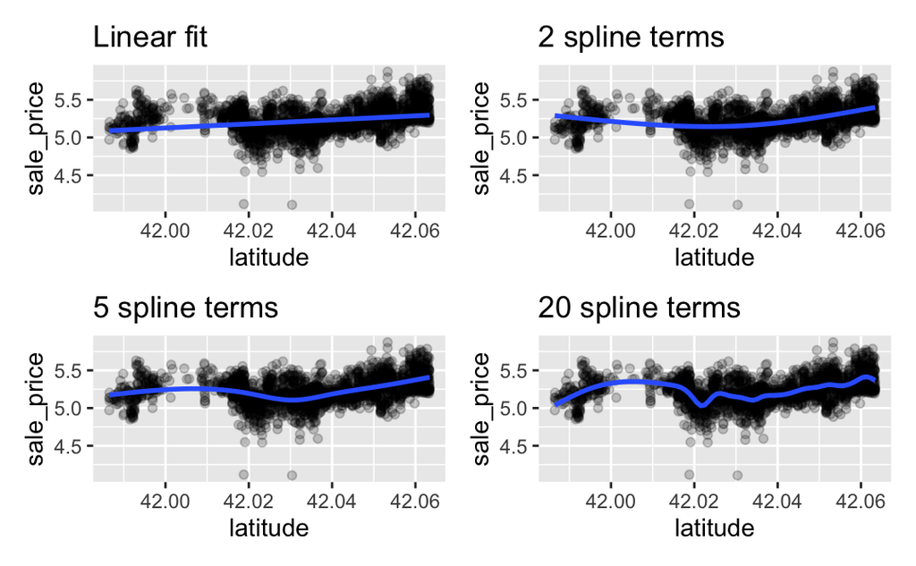

If we wanted to add a step to reduce dimensionality in the data and extract information from correlated variables, we could use `step_pca()`. It’s important to note that this step assumes that all of the predictors are on the same scale; if they are not, a normalization step in the recipe will be needed before the PCA step.

Another important consideration is information leakage- if care is not taken, steps that are meant to pre-process and perform operations for feature selection on the training set may end up being used in the same way on the test set. Recall, the test set is meant to be left as is, simulating new data drawn from the wild that the model has never seen. Thus, any steps in the recipe that center and scale the data (i.e., taking the mean and subtracting the standard deviation) are performed on the training set only, and those values are then directly applied to the test data. In other words, the mean and standard deviation are not re-calculated for the variable in the testing data.

For other transformations, however, like transforming data onto the log scale, it is recommended to perform this step outside of the recipe. This is because when a step is added to the recipe, it creates a new column in the training data only; that column does not exist in the new test data.

One important consideration for creating recipes in classification problems with high class imbalance- if downsampling is used on the majority class, that procedure should only be used on the modeling data, not on the test data used for prediction. This is where the `skip` argument to the `step_()` functions comes in- when set to `TRUE`, the pre-processing procedure is strictly applied to the modeling data.

| number | operation | type | trained | skip | id |
| --- | --- | --- | --- | --- | --- |
| 1 | step | log | FALSE | FALSE | log_OO6RY |
| 2 | step | other | FALSE | FALSE | my_id |
| 3 | step | dummy | FALSE | FALSE | dummy_bDlz5 |
| 4 | step | interact | FALSE | FALSE | interact_WmExf |
| 5 | step | ns | FALSE | FALSE | ns_1MbxZ |

Now refit the workflow.

```r
(lm_fit <- fit(lm_workflow, ames_train))
```

```
══ Workflow [trained] ═════════════════════════════════════════════════
Preprocessor: Recipe
Model: linear_reg()

── Preprocessor ───────────────────────────────────────────────────────
5 Recipe Steps

• step_log()
• step_other()
• step_dummy()
• step_interact()
• step_ns()

── Model ──────────────────────────────────────────────────────────────

Call:
stats::lm(formula = ..y ~ ., data = data)

Coefficients:
                                         (Intercept)
                                          -0.2695536
                                         gr_liv_area
                                           0.6304699
                                          year_built
                                           0.0018174
                          neighborhood_College_Creek
                                          -0.0247388
                               neighborhood_Old_Town
                                          -0.0661364
                                neighborhood_Edwards
                                          -0.1054911
                               neighborhood_Somerset
                                           0.0693337
                     neighborhood_Northridge_Heights
                                           0.1391016
                                neighborhood_Gilbert
                                           0.0215831
                                 neighborhood_Sawyer
                                          -0.1177473
                         neighborhood_Northwest_Ames
```

[output cut: 12 more lines]

```
                                           0.0049922
                             neighborhood_Northridge
                                           0.0618041
                            neighborhood_Stone_Brook
                                           0.2017678
neighborhood_South_and_West_of_Iowa_State_University
                                          -0.0094936
                            neighborhood_Clear_Creek
                                          -0.0537345
                         neighborhood_Meadow_Village
                                          -0.1510563
                              neighborhood_Briardale

...
and 100 more lines.
```

We can also include columns in the data that are helpful for identifying problematic or poorly fitted observations after the model is fitted. To do this, we can use the function `update_role()`.

| variable | type | role | source |
| --- | --- | --- | --- |
| neighborhood | nominal | predictor | original |
| gr_liv_area | numeric | predictor | original |
| year_built | numeric | predictor | original |
| bldg_type | nominal | predictor | original |
| latitude | numeric | predictor | original |
| longitude | numeric | predictor | original |
| sale_price | numeric | outcome | original |

Now save the recipe, workflow, and fit objects.